# Mice vs RGAIN

Laura Jochim

04 February, 2025

```r
#load packages
library(dplyr)
library(MASS)
library(holodeck)
library(purrr)
```

# Generate Data

To see how well the RGAIN performs in imputing missing data, I will first generate some simple data that is continuous. This data is generated using the mvrnorm function from the package MASS obtaining a multivariate normal dataset. This data set has 4 variables, where the correlations between those variables are defined in `popcor`.

```r
set.seed(11)

popcor <- matrix(nrow = 4, ncol = 4,
                 c(1, 0.5, 0.3, 0.1,
                   0.5, 1, 0.5, 0.3,
                   0.3, 0.5, 1, 0.5,
                   0.1, 0.3, 0.5, 1))
mu <- c(0, 0, 0, 0)
n_datasets <- 100
n_participants <- 2000

data <- MASS::mvrnorm(n = n_participants, mu = mu, Sigma = popcor) %>%
                       as_tibble() %>% # make into a tibble
                       rename(x1 = V1, x2 = V2, x3 = V3, x4 = V4) # rename columns
```

To save the data frame

```r
#write.csv(data, file = "C:/Users/laura/Documents/GitHub/genimp/RGAIN/gen_data.csv")
```

Now, to make the data a bit more complex, I also want it to include categorical variables, so that we can also see how well the R implementation of GAIN does when it comes to categorical variables. For that I used the sim_cat function from the package holodeck to generate 2 categorical variables adding to the previous data set. One variable has three and the other four categories.

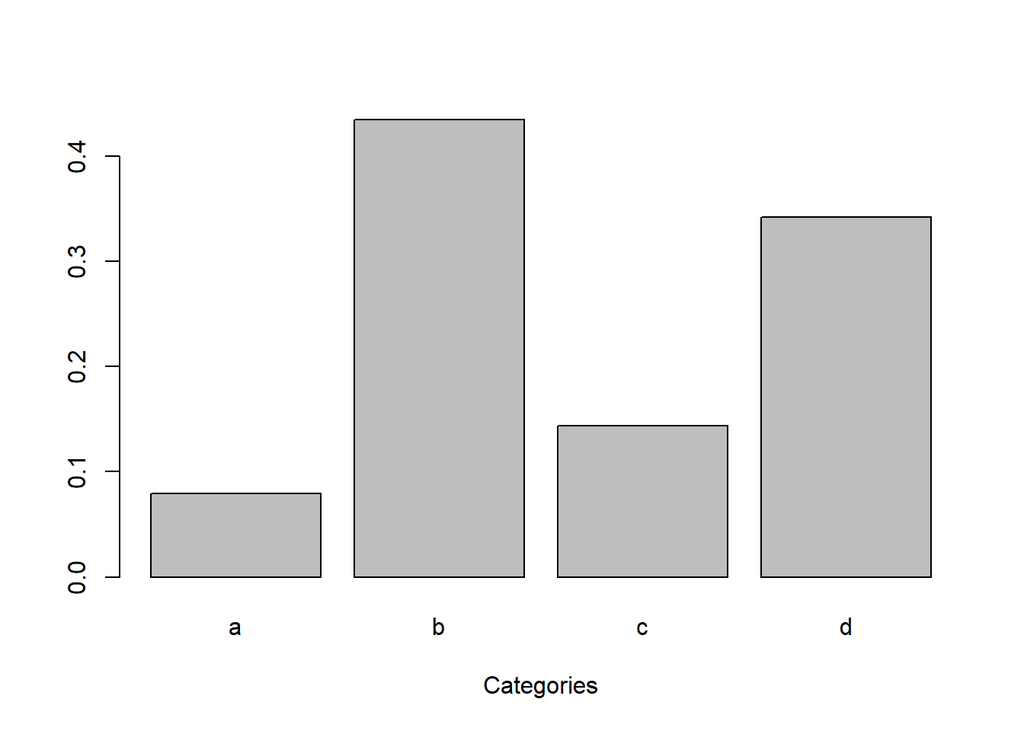

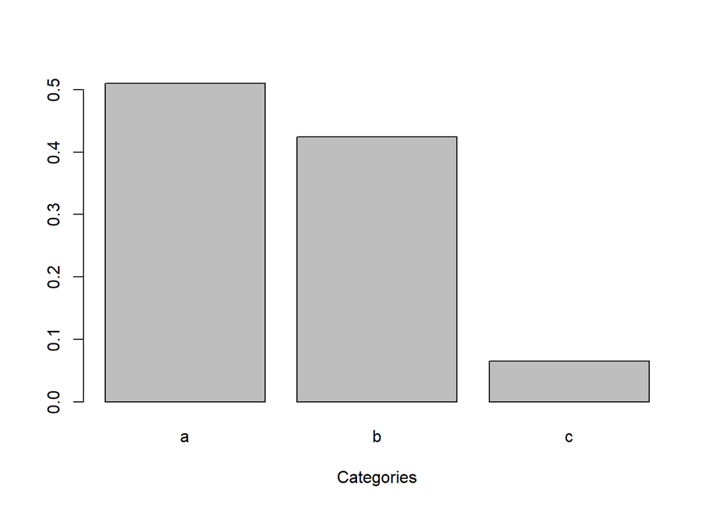